# R for Clinical Study Reports and Submission

December 2021

## Welcome

## Outline

In this workshop, we have three parts:

- Delivering TLFs in CSR (Yilong Zhang)
  - Session 1 (45 min)
  - Break and/or Exercise (20 min)
  - Session 2 (45 min)
  - Break (10 min)
- Clinical trial project (Nan Xiao)
  - Session 3 (30 min)
  - Break (10 min)
- eCTD submission package (Nan Xiao)
  - Session 4 (40 min)
  - Q&A (10 min)

## Disclaimer

- All opinions expressed are those of the presenter and not Merck Sharp & Dohme Corp., a subsidiary of Merck & Co., Inc., Kenilworth, NJ, USA.
- Some slides need to be scrolled down to see the full content.

## Training objective

- Learning how to create tables for clinical study reports.
- Learning how to organize a clinical development project.
- Learning how to prepare eCTD submission package to FDA.

> The toolchain, process, and formats may be different in different organizations. We only provide a recommended way to address them.

## Acknowledgement

- Team members from Merck & Co.
  - [We are hiring!](https://jobs.merck.com/bards)
  - Contact us if interested.
- [Contributors](https://r4csr.org/) of the training materials.
  - Please consider submitting issues or PR in the repo.
- [R Consortium](https://www.r-consortium.org/all-projects/isc-working-groups)
  - R validation hub
  - Submission working group
  - R Tables for Regulatory Submission (RTRS) working group
  - Please consider to join and contribute to a working group.
- [ASA Princeton-Trenton Chapter](https://community.amstat.org/princetontrenton/home)
  - Please consider to be a member of our chapter.

## Preparation

In this workshop, we assume you have some R programming experience and clinical development knowledge.

- Data manipulation: tidyverse, dplyr, tidyr, ggplot2 etc.
- ADaM data: `adsl`, `adae` etc.

```r
install.packages(c(
  "tidyverse", # Data manipulation
  "r2rtf",     # TLF generation
  "pkglite"    # eCTD submission
))
```

## Resource

- Training Material: https://r4csr.org/
- Demo project:
  - Analysis project: https://github.com/elong0527/esubdemo
  - eCTD submission package: https://github.com/elong0527/ectddemo
- R Consortium FDA submission pilot:
  - https://github.com/RConsortium/submissions-pilot1
- During the workshop, we will use `esubdemo` project.
  - `esubdemo` is shared in Posit Cloud (https://posit.cloud/)
  - Project link will be shared in chat
  - Post questions in group chat.

## Philosophy

We share the same philosophy described in [Section 1.1 of the R Packages book](https://r-pkgs.org/introduction.html#intro-phil) and quote here.

- “Anything that can be automated, should be automated.”
- “Do as little as possible by hand. Do as much as possible with functions.”
- “The goal is to spend your time thinking about what you want to do rather than thinking about the minutiae of package structure.”

## Delivering TLFs in CSR

## ICH E3 guidance

The [ICH E3: structure and content of clinical study reports](https://database.ich.org/sites/default/files/E3_Guideline.pdf) provide guidance to assist sponsors in the development of a CSR.

In a CSR, most of TLFs are located in

- Section 10: Study patients
- Section 11: Efficacy evaluation
- Section 12: Safety evaluation
- Section 14: Tables, Figures and Graphs referred to but not included in the text
- Section 16: Appendices

## Datasets

- Public available CDISC pilot [study data located at CDISC GitHub repository](https://github.com/cdisc-org/sdtm-adam-pilot-project/tree/master/updated-pilot-submission-package/900172/m5/datasets/cdiscpilot01/analysis/adam/datasets).
- The dataset structure follows the [CDISC Analysis Data Model (ADaM)](https://www.cdisc.org/standards/foundational/adam).
- Source data: https://github.com/elong0527/r4csr/tree/master/data-adam

## Tools

- tidyverse: a collection of R packages to simplify the workflow to manipulate, visualize and analyze data in R.
- r2rtf: an R package to create production-ready tables and figures in RTF format.

## r2rtf introduction

## Motivation

In the pharmaceutical industry, RTF/Microsoft Word play a central role in preparing clinical study reports

- [ICH E3 Structure and Content of Clinical Study Reports](https://database.ich.org/sites/default/files/E3_Guideline.pdf)

Different organizations can have different table standards

- E.g., Table layout, Font size, Border type, Footnote, Data source
- r2rtf is an R package to create production-ready tables and figures in RTF format.

r2rtf is designed to:

- provide simple “verb” functions that correspond to each component of a table, to help you translate a data frame to a table in RTF format;
- enable pipes (`%>%`);
- only focus on the **table format**.
  - Data manipulation and analysis should be handled by other R packages. (e.g., tidyverse)

## Workflow

Before creating an RTF table, we need to:

- Figure out table layout.
- Split the layout into small tasks in the form of a computer program.
- Execute the program.

## Minimal example

r2rtf is designed to enable pipes (`%>%`).

```r
head(iris) %>%
  rtf_body() %>%           # Step 1 Add table attributes
  rtf_encode() %>%         # Step 2 Convert attributes to RTF encode
  write_rtf("minimal.rtf") # Step 3 Write to a .rtf file
```

[figure not shown]

## Package overview

r2rtf package provides the flexibility to customize table appearance for

- **Table component**: title, column header, footnote, etc.
- **Table cell style**: size, border type, color, font size, text color, alignment, etc.
- **Flexible control**: the specification of the cell style can be row or column vectorized.
- **Complicated format**: pagination, section grouping, multiple table concatenations, etc.

r2rtf package also provides the flexibility to convert figures in RTF format.

## Simple example: adverse events

r2rtf only focus on **table format**. Data manipulation and analysis should be handled by other R packages. (e.g., tidyverse)

- Let’s refer to examples in the [Section 1.4.2](https://r4csr.org/tlf-overview.html#r2rtf)

## Function summary

r2rtf provides simple “verb” functions that correspond to each component of a table, to help you translate data frame to tables in RTF file.

| Functions | Purpose | Optional/required |
| --- | --- | --- |
| rtf_page_header() | add page header | optional |
| rtf_title() | add title | optional |
| rtf_subline() | add subject line | optional |
| rtf_colheader() | add column header | optional |
| rtf_body() | add table body | required |
| rtf_footnote() | add footnote | optional |
| rtf_source() | add data source | optional |
| rtf_page_footer() | add page footer | optional |
| rtf_encode() | convert table into rtf code | required |
| write_rtf() | write rtf code into .rtf file | required |

## Function illustration

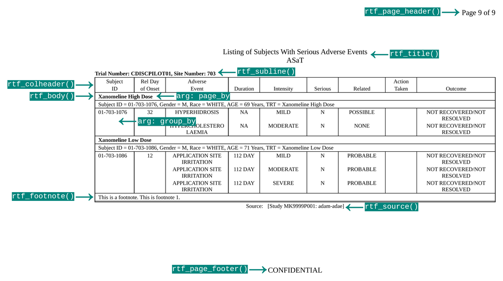

## Break and/or exercise (20 min)

## CSR examples

## Disposition table

https://r4csr.org/tlf-disposition.html

## Analysis population

https://r4csr.org/tlf-population.html

## Baseline characteristics

https://r4csr.org/tlf-baseline.html

## Efficacy table

https://r4csr.org/tlf-efficacy-ancova.html

## AE Summary table

https://r4csr.org/tlf-ae-summary.html

## Specific AE table

https://r4csr.org/tlf-ae-specific.html

## Break (10 min)

## Clinical trial project

## Overview

In a late-stage clinical trial, the number of A&R deliverables can easily be in the hundreds.

For an organization, it is also common to have multiple ongoing clinical trials in a clinical program.

In this part, let’s consider how to organize a clinical trial project as an A&R lead.

## Folder structure

Our primary focus is creating a standard R package structure to organize the project, with 4 goals in mind:

- Consistency
- Reproducibility
- Automation
- Compliance

https://r4csr.org/project-folder.html

## Project management

- Setting up for success
  - Teamwork
  - Architecture
  - Boundaries
  - Community
- The SDLC
  - Planning
  - Development
  - Validation
  - Operation

https://r4csr.org/project-management.html

## Break (10 min)

## eCTD submission

## Overview

https://r4csr.org/submission-overview.html

## Submission package

We will discuss strategies to prepare proprietary R packages and analysis code into proper formats for submission:

- The whole game
- Practical considerations
- Prepare R packages using `pkglite`
- Prepare analysis programs
- Update ADRG and ARM

https://r4csr.org/submission-package.html

## Running environment

We will also give recommendations to make the R code running environment reproducible for dry run tests and reviews using `cleanslate`.

https://r4csr.org/submission-environment.html

## pkglite

## pkglite: compact package representations

- To provide a **tool** for packing and restoring R packages as plaintext assets that are easy to store, transfer, and review.
- To provide a **grammar** for specifying the file packing scope that is functional, precise, and extendable.
- To provide a **standard** for exchanging the packed asset that is unambiguous, human-friendly, and machine-readable.

## Pipe-friendly workflow

```r
library("pkglite")

"/path/to/pkg/" %>%
  collate(file_ectd()) %>%
  pack()

pack(
  "/path/to/pkg1/" %>% collate(file_ectd()),
  "/path/to/pkg2/" %>% collate(file_ectd()),
  output = "/path/to/pkglite.txt"
)

"/path/to/pkglite.txt" %>%
  unpack(output = "/path/to/output/")
```

## File specifications + file collections

File specifications offer flexibility and brevity in specifying the files to include.

| File specification type | Functions |
| --- | --- |
| Manual discovery | `file_spec()` |
| Automatic discovery | `file_auto()` |
| Common patterns | `file_root_core()`, `file_r()`, `file_man()`, `file_src()`, `file_vignettes()`, … |
| Default sets | `file_default()`, `file_ectd()` |

File collections contain the evaluation results of file specifications for packing.

```r
library("pkglite")

"/path/to/pkg" %>%
  collate(file_root_core(), file_r(), file_auto("inst/"))
```

## pkglite.txt

pkglite.txt follows the standard Debian Control File (DCF) format used by Debian, R, and RStudio IDE, to be both machine-readable and human-readable.

```
# Generated by pkglite: do not edit by hand
# Use pkglite::unpack() to restore the packages

Package: pkg1
File: DESCRIPTION
Format: text
Content:
  Package: pkg1
  Type: Package
  Title: Example Package One
  Version: 0.1.0
```